# Bern02_hierarchical_models_and_testing(1)

Parts of this notebook are adapted from examples in https://github.com/luchem/bern02 (Jens Uhlig, Mikael Lund, Ullrika Sahlin), licensed under CC BY-SA 4.0. Modified and extended by Roland Hansson. This notebook is also licensed under [CC BY-SA 4.0](https://creativecommons.org/licenses/by-sa/4.0/).

## Introduction

In this article, we study towel reuse in hotels, in two groups: guests who are told that the norm is to reuse towels (treatment group), vs guests who are told that reusing towels are good for the environment (control).

(A third group not being told anything would give good data, but alas there was none.)

```python
pip install bambi
```

[output not shown]

[output not shown]

[output not shown]

[output not shown]

[output not shown]

[output not shown]

We were given access to an article about this problem (1).

Unfortunately it uses the same data as us, otherwise we could piggyback on that data to make a *really good* prior.

The appropriate family distribution for a response variable p is Binomial, but the beta-binomial variant seems more forgiving.

```python
import pandas as pd
import numpy as np

#(This part copied from the excercise instructions without modification.)

# read in data
data_file = "towelData.csv"
data = pd.read_csv(data_file, sep=';', encoding='latin1')
count = data.iloc[:, -1] # get the last column with numbers or yes/no

# count has the number of yes and no for control and social norm groups
control_yes = count[::4].to_numpy() # every 4th starting from 0 - control group + yes
control_no = count[2::4].to_numpy() # every 4th starting from 2 - control group + no
control_total = np.array([y + n for y, n in zip(control_yes, control_no)])

social_yes = count[1::4].to_numpy() # every 4th starting from 1 - social norm group + yes
social_no = count[3::4].to_numpy() # every 4th starting from 3 - social norm group + no
social_total = np.array([y + n for y, n in zip(social_yes, social_no)])

study = np.arange(1,len(control_yes)+1) # 7 diferent studies

control_data = pd.DataFrame({"reuse": control_yes, "total": control_total, "group": "control", "study": study})
social_data = pd.DataFrame({ "reuse": social_yes, "total": social_total, "group": "social", "study": study})

combined_data = pd.concat([control_data, social_data], ignore_index=True)

# Convert data types - important for bambi that they are correctly set
# can give errors otherwise
combined_data['reuse'] = combined_data['reuse'].astype(int)
combined_data['total'] = combined_data['total'].astype(int)
combined_data['group'] = combined_data['group'].astype('category')
combined_data['study'] = combined_data['study'].astype('category')

# See first rows
print(combined_data)
```

```
    reuse  total    group study
0      74    211  control     1
1     103    277  control     2
2      77    135  control     3
3      82    187  control     4
4      21     25  control     5
5     123    147  control     6
6      28     30  control     7
7      98    222   social     1
8     587   1318   social     2
9     406    655   social     3
10    278    555   social     4
11     21     24   social     5
12    472    576   social     6
13    101    132   social     7
```

With studies coming from different locations, there is likely a specific slope and intercept for each study location because of differing cultural values.

The countries of origin seem to be the US, Germany and Australia, making for three groups to consider, but to get a more powerful model, we simply divided the different studies into "US" and "non-US" countries.

```python
#Adding data on study origin country, using information from article
# ( "Bayesian Evidence Synthesis Can Reconcile Seemingly Inconsistent Results: The Case of Hotel Towel Reuse",
# Psychological Science 2016, Vol. 27(7) 1043 –1046)

country_map = {
    1: "USA",       # Goldstein et al. 2008, Exp 1
    2: "USA",       # Goldstein et al. 2008, Exp 2
    3: "USA",       # Schultz et al. 2008, Exp 2
    4: "USA",       # Schultz et al. 2008, Exp 3
    #5: "Australia",  # Mair & Bergin-Seers 2010, Exp 1
    #6: "Germany",    # Bohner & Schlüter 2014, Exp 1
    #7: "Germany",    # Bohner & Schlüter 2014, Exp 2
    5: "non-US",  # Mair & Bergin-Seers 2010, Exp 1
    6: "non-US",    # Bohner & Schlüter 2014, Exp 1
    7: "non-US",    # Bohner & Schlüter 2014, Exp 2
}

combined_data["country"] = combined_data["study"].map(country_map).astype("category")
```

Three possible hypotheses were made:

H0: Stated norms have no impact.

H1: Stated norms have the same impact in US countries and non-us countries.

H2: Stated norms have different impacts in US countries and non-us countries.

These models were tested according to bayesian statistics.

```python
#()import arviz as az
# print(az.__version__)
import bambi as bmb
import matplotlib.pyplot as plt
from matplotlib.lines import Line2D
from matplotlib.patches import Patch


#Null hypothesis: group has no impact on reuse.
priors = {
    "Intercept": bmb.Prior("Normal", mu=0, sigma=1.5),
    "1|country": bmb.Prior("Normal", mu=0, sigma=bmb.Prior("HalfNormal", sigma=0.5)),   # prior on the SD of study effects
}

model_null = bmb.Model("p(reuse, total) ~ 1 + (1|country)", combined_data, family="beta_binomial", priors=priors)
results_null = model_null.fit(draws=1000, target_accept=0.95, idata_kwargs={"log_likelihood": True})


#H1: group has same impact in all countries

priors = {
    "Intercept": bmb.Prior("Normal", mu=0, sigma=1.5),
    "group": bmb.Prior("Normal", mu=0, sigma=1),                                   # one prior, one coefficient
    "1|country": bmb.Prior("Normal", mu=0, sigma=bmb.Prior("HalfNormal", sigma=0.5)),   # prior on the SD of study effects

}

# Initialize the fixed effects only model
model_hierarchical = bmb.Model("p(reuse, total) ~ 1 + group + (1|country)", combined_data, family="beta_binomial", priors=priors)
model_hierarchical

# Get model description
print(model_hierarchical)

# Fit the model using 1500 on each chain
results = model_hierarchical.fit(draws=1500, tune=1500, target_accept=0.95, idata_kwargs={"log_likelihood": True})


#H2: group has different impact in US and the rest of the world

priors = {
    "Intercept": bmb.Prior("Normal", mu=0, sigma=1.5),
    "group": bmb.Prior("Normal", mu=0, sigma=1),                                   # one prior, one coefficient
    "1|country": bmb.Prior("Normal", mu=0, sigma=bmb.Prior("HalfNormal", sigma=0.5)),   # prior on the SD of study effects

}
model_interaction = bmb.Model(
    "p(reuse, total) ~ 1 + group * country + (1|country)",
    combined_data, priors = priors,
    family="beta_binomial"
)
model_interaction
results_interaction = model_interaction.fit(draws=1500, target_accept=0.95, idata_kwargs={"log_likelihood": True})
```

```
       Formula: p(reuse, total) ~ 1 + group + (1|country)
        Family: beta_binomial
          Link: mu = logit
  Observations: 14
        Priors:
    target = mu
        Common-level effects
            Intercept ~ Normal(mu: 0.0, sigma: 1.5)
            group ~ Normal(mu: 0.0, sigma: 1.0)

        Group-level effects
            1|country ~ Normal(mu: 0.0, sigma: HalfNormal(sigma: 0.5))

        Auxiliary parameters
            kappa ~ HalfCauchy(beta: 1.0)
```

```python
print(combined_data.shape)
print(combined_data["study"].unique())
print(combined_data["study"].nunique())

# What does the posterior actually contain?
print(results_null.posterior["1|country"].coords)
print(results_null.posterior["1|country"].shape)


results_null.posterior["1|country"].sel(chain=0)
results_null.posterior["1|country"].sel(chain=1)
```

```
(14, 5)
[1, 2, 3, 4, 5, 6, 7]
Categories (7, int64): [1, 2, 3, 4, 5, 6, 7]
7
Coordinates:
  * chain                (chain) int64 16B 0 1
  * draw                 (draw) int64 8kB 0 1 2 3 4 5 ... 995 996 997 998 999
  * country__factor_dim  (country__factor_dim) <U6 48B 'USA' 'non-US'
(2, 1000, 2)
```

```
<xarray.DataArray '1|country' (draw: 1000, country__factor_dim: 2)> Size: 16kB
array([[-0.45549216,  0.47930884],
       [-0.65142226,  1.22342524],
       [-1.01801861,  0.59870827],
       ...,
       [-0.70434551,  0.73206495],
       [-1.47488526,  0.12099877],
       [-1.20782294,  0.53798457]])
Coordinates:
  * draw                 (draw) int64 8kB 0 1 2 3 4 5 ... 995 996 997 998 999
  * country__factor_dim  (country__factor_dim) <U6 48B 'USA' 'non-US'
    chain                int64 8B 1
```

## Results

We got some results from these simulations, but they were not very promising.

```
null hypothesis
```

```
                    mean    sd eti90_lb eti90_ub ess_bulk ess_tail r_hat mcse_mean mcse_sd
kappa                 33    18       10       68      816      643  1.00      0.59    0.68
Intercept            0.6  0.53    -0.28      1.5      698      816  1.00      0.02   0.018
1|country_sigma     0.77  0.25     0.41      1.2      568      570  1.00    0.0099  0.0069
1|country[USA]     -0.68  0.53     -1.6     0.19      712      748  1.00      0.02   0.018
1|country[non-US]   0.87  0.55   -0.017      1.8      624      747  1.01     0.022   0.016

H1 hypothesis
```

```
                    mean     sd eti90_lb eti90_ub ess_bulk ess_tail r_hat mcse_mean mcse_sd
kappa               32.5     20      9.7       71     1804     1640  1.00      0.46     0.6
Intercept           0.53   0.56    -0.41      1.4     1016     1298  1.00     0.018   0.014
group[social]       0.12   0.24    -0.28      0.5     2245     1740  1.00    0.0052  0.0061
1|country_sigma     0.77  0.237     0.44      1.2     2003     1807  1.00    0.0051  0.0045
1|country[USA]     -0.68   0.55     -1.6     0.23     1024     1234  1.00     0.017   0.014
1|country[non-US]   0.88   0.56    0.015      1.8     1021     1251  1.00     0.018   0.014

H2 hypothesis
```

```
                                mean     sd eti90_lb eti90_ub ess_bulk ess_tail r_hat mcse_mean mcse_sd
kappa                             37     22       12       80     1809     1984  1.00       0.5     0.7
Intercept                      -0.25   0.46       -1     0.54     1088     1178  1.00     0.015   0.015
group[social]                   0.27   0.27    -0.16     0.69     1869     1883  1.00    0.0063  0.0063
country[non-US]                 2.04   0.76     0.79      3.3     1340     1293  1.00     0.021   0.021
group:country[social, non-US]  -0.65   0.58     -1.6      0.3     1680     1471  1.00     0.014   0.013
1|country_sigma                 0.38  0.282     0.03     0.91      844      901  1.00    0.0084  0.0046
1|country[USA]                 -0.02   0.43    -0.78      0.7     1021     1029  1.00     0.014   0.015
1|country[non-US]               0.03   0.45    -0.66      0.8     1302     1289  1.00     0.013   0.016

comparison
       rank  elpd_diff   dse  p_worse diag_diff diag_elpd    p  elpd   se  \
null      0        0.0  0.00      NaN                      2.2 -60.0  5.2
full1     1       -1.0  0.57      0.9   N < 100            2.8 -60.0  5.1

       weight
null      1.0
full1     0.0

comparison
```

```
       rank  elpd_diff  dse  p_worse diag_diff diag_elpd    p  elpd   se  \
null      0        0.0  0.0      NaN                      2.2 -60.0  5.2
full2     1       -0.0  1.3     0.64   N < 100            3.4 -60.0  5.1

       weight
null     0.77
full2    0.23
```

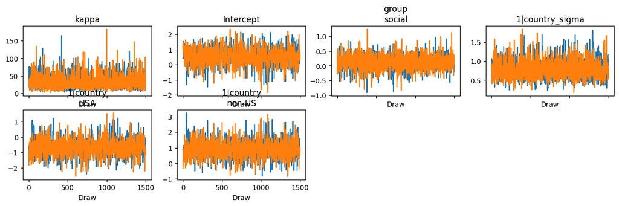

```python
import arviz as az
#print(az.__version__)
import bambi as bmb
import pandas as pd

# Parameters
conf_interval = 0.9
pd.set_option("display.max_rows", None)

# Use ArviZ to plot the results
az.plot_trace(results)


#Make a summary of the parameter values by the posterior mean and 90% probability interval.

# Null hypothesis
print("null hypothesis")
pd.set_option("display.max_rows", None)
summary_null = az.summary(results_null, ci_prob=0.9).round(3)
print(summary_null)


# Key summary and diagnostic info on the model parameters
print()
print("H1 hypothesis")
pd.set_option("display.max_rows", None)
summary = az.summary(results, ci_prob=0.9).round(3)
print(summary)


print()
print("H2 hypothesis")
pd.set_option("display.max_rows", None)
summary_interaction = az.summary(results_interaction, ci_prob=0.9).round(3)
print(summary_interaction)


#Making comparisons:

print()
print("comparison")
comparison = az.compare({
    "null": results_null,
    "full1": results
})
print(comparison)

print()
print("comparison")
az.summary(results_null, ci_prob=0.9)
comparison = az.compare({
    "null": results_null,
    "full2": results_interaction
})
print(comparison)



#Formulate hypotheses for the test of the effectiveness of the intervention referring to one or several parameters within the model.
```

```python
#Test the hypothesis using Bayesian inference.
#Calculate Bayes factor

#BF = prob_model/prob_null
#print(BF)

import numpy as np
from scipy import stats
print(list(results_interaction.posterior.data_vars))
interaction_samples = results_interaction.posterior["group:country"].values.flatten()
hierarchy_samples = results.posterior["group"].values.flatten()

# Posterior density at 0
kde = stats.gaussian_kde(hierarchy_samples)
posterior_density_at_0 = kde(0)[0]

# Prior density at 0 - fill in mu/sigma from what model_interaction printed
prior_density_at_0 = stats.norm(loc=0).pdf(0)

BF_01 = posterior_density_at_0 / prior_density_at_0
BF_10 = 1 / BF_01

print(f"BF_01 (evidence for 'no interaction/no difference' over 'same slope'): {BF_01:.3f}")
print(f"BF_10 (evidence for 'same slope' over 'no interaction'): {BF_10:.3f}")

# Posterior density at 0
kde = stats.gaussian_kde(interaction_samples)
posterior_density_at_0 = kde(0)[0]

# Prior density at 0 - fill in mu/sigma from what model_interaction printed
prior_density_at_0 = stats.norm(loc=0).pdf(0)

BF_02 = posterior_density_at_0 / prior_density_at_0
BF_20 = 1 / BF_02

print(f"BF_01 (evidence for 'no interaction/no difference' over 'different slopes'): {BF_02:.3f}")
print(f"BF_10 (evidence for 'different slopes' over 'no interaction'): {BF_20:.3f}")
```

```
['kappa', 'Intercept', 'group', 'country', 'group:country', '1|country_sigma', '1|country']
BF_01 (evidence for 'no interaction/no difference' over 'same slope'): 3.698
BF_10 (evidence for 'same slope' over 'no interaction'): 0.270
BF_01 (evidence for 'no interaction/no difference' over 'different slopes'): 0.854
BF_10 (evidence for 'different slopes' over 'no interaction'): 1.171
```

There were three hypotheses: H0: Stated norms have no impact. H1: Stated norms have the same impact in US countries and non-us countries. H2: Stated norms have different impacts in US countries and non-us countries.

Overall, we could not find compelling reason to reject H0; while H2 is the more likely model, a Bayes factor of 1.2 is not significant at all. You need something above 3.

We can say, however, that H1 seems like the least likely model; H0 has a Bayes factor of 3.7 over H1, more than three times worse than the null hypothesis.

Many of the calculated variables, in all models, have a zero within their confidence interval, which is bad.

With more data available, these calculations might get different results.

Setting more specific priors might also be helpful. We tried something different from the paper, and were clearly not as skilled.

## Appendix

1. Scheibehenne, B. (University of Geneva), Jamil, T. (University of Amsterdam), & Wagenmakers, E.-J. (University of Amsterdam) (2016). Bayesian Evidence Synthesis Can Reconcile Seemingly Inconsistent Results: The Case of Hotel Towel Reuse. Psychological Science, 27(7), 1043–1046. DOI: 10.1177/0956797616644081

```python
import sys
from importlib.metadata import version

print("Python", sys.version.split()[0])
for pkg in ["numpy", "pandas", "bambi", "scipy", "pymc", "arviz", "matplotlib"]:  # edit to your imports
    print(f"{pkg}=={version(pkg)}")
```

```
Python 3.13.16
numpy==2.1.3
pandas==2.2.3
bambi==0.21.0
scipy==1.16.3
pymc==6.3.2
arviz==1.3.0
matplotlib==3.10.0
```

```python
#!jupyter nbconvert --execute --to html "/content/Bern02_hierarchical_models_and_testing(1).ipynb"
```